# Google searches and stock prices

ttmmghmm

12/20/2014

# 1 section one

[ref 1](http://www.nature.com/srep/2013/130508/srep01801/full/srep01801.html)

[ref 2](http://www.wired.co.uk/news/archive/2013-05/8/wikipedia-views-stock-market)

Previous research has shown that the

- volume of financially-related searches on Google
  - http://www.nature.com/srep/2013/130425/srep01684/full/srep01684.html
- “mood” of tweets on Twitter can be linked to changes in the stock market.
  - Measuring how calm the Twitterverse is on a given day can foretell the direction of changes to the Dow Jones Industrial Average three days later with an accuracy of 86.7 percent.
  - one emotion, calmness, lined up surprisingly well with the rises and falls of the stock market – but three or four days in advance.
  - predict whether the stock market would go up or down, first using only the Dow Jones Industrial Average from the past three days, then including emotional data.
    - The algorithm did pretty well using stock market data alone, predicting the shape of the stock market with 73.3 percent accuracy. But it did even better when the emotional information was added, reaching up to 86.7 percent accuracy.
  - http://www.wired.co.uk/news/archive/2010-10/20/twitter-predicts-the-stock-market
    - http://arxiv.org/abs/1010.3003
- views of Wikipedia pages
  - correlation with a fall in share price, rather than a rise, could be because of humans’ risk-averse nature.
  - http://www.nature.com/srep/2013/130508/srep01801/full/srep01801.html
  - http://dumps.wikimedia.org/other/pagecounts-raw/

http://www.nature.com/srep/2013/130425/srep01684/full/srep01684.html http://www.wired.co.uk/news/archive/2010-10/20/twitter-predicts-the-stock-market

- profits of up to 141 percent higher than a random trading strategy, the researchers found. ** “In our strategy, we sold the [Dow Jones Industrial Average (DJIA)] if people had recently looked at a financially related page more than in earlier weeks, and closed the position a week later,” explained Moat. “If people had recently looked at a financially related page less than in earlier weeks, we bought the DJIA and closed the position a week later.”
- Monitoring pages related to financial topics, such as macroeconomics and capital, would have generated profits of up to 297 percent.

The frequency of Wikipedia *edits*, as opposed to *views*, showed little or no correlation with stock market movements, probably because the same people who edit Wikipedia pages are not the same people who make decisions on the stock market.

The researchers also examined non-financial Wikipedia pages, such as pages about famous actors, and found no correlation. Data about Wikipedia page views was gathered from stats.grok.se

# 2

# 3 A Minimal Example for Markdown

This is a minimal example of using **knitr** to produce an *HTML* page from *Markdown*.

## 3.1 R code chunks

Now we write some code chunks in this markdown file:

```
## [1] -0.56048 -0.23018  1.55871  0.07051  0.12929
```

We can also produce plots:

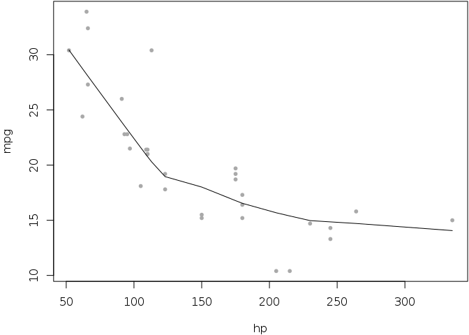

## 3.2 Inline code

Inline R code is also supported, e.g. the value of `x` is 2, and 2 × π = 6.2832.

## 3.3 Math

LaTeX math as usual: $f(\alpha, \beta) \propto x^{\alpha-1}(1-x)^{\beta-1}$.

## 3.4 Misc

You can indent code chunks so they can nest within other environments such as lists.

1. the area of a circle with radius x

   ```
   ## [1] 12.57
   ```

2. OK, that is great

## 3.5 Conclusion

Markdown is super easy to write. Go to **knitr** [homepage](http://yihui.name/knitr) for details.